# Heat and Predators: Understanding Shark Attacks in a Complex Environment

Noel Demko, Manal Moubtassim, Jean Carlos Perez Perilla, Elias Zakarya

25/10/2023

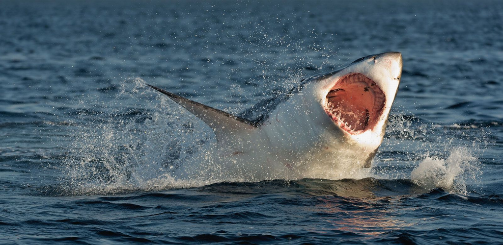

© USO—iStock/Getty Images

# 1. **Introduction**

## 1.1 Background and Motivation

At first, we wanted to analyse the impacts of the recent global pandemic on individuals within the context of a variety of mental health conditions, namely anxiety and depression, in a pre- and post-COVID framework. However, we decided to drop the idea due to a lack of data available regarding the topic, which wouldn’t have allowed us to conduct a thorough analysis. As we were searching for new topic ideas, we found a dataset that concerns shark attacks around the world. A group member has then told us about an incident that occurred during his last holidays in Egypt, involving a shark attack at a paradisiac beach. We discussed thereafter the presence of these predators in many different regions in the world including Florida, Hawaii, and Australia just to name a few. For this reason, we decided to dive deeper into the topic of shark attacks and explore potential influencing factors. After a few days of research and information gathering, we found that a wide range of factors are capable of influencing such incidents, both directly and indirectly. We all enjoy going on holidays and enjoy beaches while drinking a cocktail, and when we feel that temperature increases, we go in the water to refresh, but depending on the location we are, this could be unsafe.

Another motivation behind this project is our interest in the preservation of marine fauna. Very often human beings tend to primarily blame the animals for their fierce behavior (just look at the example of the attack that occurred in Hurghada during summer of 2023: after the death of the victim, the shark was killed!) but we often forget that the water it is their natural habitat, and that we are the guests. This point motivates us even more to study the phenomenon of attacks and to disclose how human activity causes shark attacks.

## 1.2 Project Objective

The project’s focus is to provide an understanding of the complex dynamics of shark attacks globally, by conducting an in-depth analysis on the different factors that influence the phenomenon. In addressing the topic at hand, we explore both direct and indirect influencing factors.

At the end of our work we want to learn how it is possible to reduce accidents caused by sharks. On the one hand, this is crucial to guarantee the safety of people who take pleasure in coastal waters and engage in water-related activities. On the other hand, the conservation of aquatic animals might benefit from this. Making efforts to preserve these species is essential for sustaining the health of marine ecosystems in a time when the extinction rate of many animal species is rising. Among the factors that might have an impact on the trend of shark attacks we have climatic variations. Ocean temperatures and currents are capable of affecting migration patterns and habitat preferences, which further complicates the dynamics of shark attacks. By providing a step-by-step analysis on climate-related aspects, we aim to provide empirical evidence on the impact of environmental changes on shark movements and interactions with humans.

This project’s goal is to contribute to the understanding of shark-related incidents and thereby to provide possible strategies such as policymaking, which would help mitigate such occurrences, ultimately safeguarding human life and protecting sharks. In essence, we aim to advance research on sustainable coexistence with the marine environment through actionable insights and intend to contribute to the broader efforts of marine conservation.

## 1.3 Related Work

To have a global overview of the phenomenon, we also read some papers, here are some of them:

1. https://journals.plos.org/plosone/article?id=10.1371/journal.pone.0211049)
2. https://www.publish.csiro.au/mf/pdf/MF10181

What is more, while gathering information on Google Scholar, we found that this topic stirred up a considerable amount of discussion and analysis, and this was yet another compelling argument to investigate it further, by adding some points of discussion that have not been explored yet.

At this point we all agreed and decided to pursue this project.

## 1.4 Research Questions

1. What are the primary factors influencing the occurrence of shark attacks?
2. Is it true that shark attacks have been increasing with climate change?
3. What are the main factors leading to the fatality of a shark attack?

# 2. **Data Sets**

In the second section of our work, we will present the datasets that are necessary to answer our research questions. These datasets serve as the foundation for our investigation and provide the data required to draw insightful and important findings. The purpose of this part is to provide a clear overview of the data landscape and make clear to the reader what are the information to be found in each web-based data, and how do they interrelate.

## 2.1 Shark Attacks Data Set

Our first dataset contains the information in over 6000 shark attacks that have occurred worldwide over the course of the past centuries. The dataset was obtained from the Shark Research Institute’s (SRI) website, which carries out and funds rigorous, peer-reviewed shark field research and instructs people using scientific data.

Even though the dataset is owned by the SRI, we have downloaded it through the following plateform: https://www.kaggle.com/datasets/teajay/global-shark-attacks.

```r
# Create a 2x2 table. The first column represents the name of variables, the second one the description of each variable

Variables <- c("Case Number", "Date", "Year", "Type", "Country", "Area", "Location", "Activity", "Name", "Sex", "Age", "Injury", "Fatal", "Time", "Species", "Investigator.or.Source", "pdf", "href.formula", "Case Number 2")
Description <- c("Case Number of accident", "Date of the accident", "Year of accident", "Whether the victim provoked the shark or not", "Country of accident", "Region", "Location", "Activity the victim was doing before accident","Name of the victim", "Sex of the victim", "Age of the victim","Injury provoked by the accident", "Whether the accident led to death or not (Binary variable)", "Time of accident", "Shark Species", "Investigator of the accident", "Pdf information of the accident", "Pdf link of the accident", "Case number (same aas the first one)")


Table1 <- data.frame(Variable = Variables, Description = Description)

# The knitr::kable() allows to visualize the table
knitr::kable(Table1)
```

| Variable | Description |
| --- | --- |
| Case Number | Case Number of accident |
| Date | Date of the accident |
| Year | Year of accident |
| Type | Whether the victim provoked the shark or not |
| Country | Country of accident |
| Area | Region |
| Location | Location |
| Activity | Activity the victim was doing before accident |
| Name | Name of the victim |
| Sex | Sex of the victim |
| Age | Age of the victim |
| Injury | Injury provoked by the accident |
| Fatal | Whether the accident led to death or not (Binary variable) |
| Time | Time of accident |
| Species | Shark Species |
| Investigator.or.Source | Investigator of the accident |
| pdf | Pdf information of the accident |
| href.formula | Pdf link of the accident |
| Case Number 2 | Case number (same aas the first one) |

## 2.2 Temperatures Data Set

Our second dataset contains the average temperature change for each country (annually, monthly and seasonally) from 1961 to 2022. It contains 9,657 observations.

The dataset was taken from the website of the Food and Agriculture Organization of United Nations: https://www.fao.org/faostat/en/#data/ET

```r
# Create a 2x2 table. The first column represents the name of variables, the second one the description of each variable

Variables <- c("Area Code", "Area", "Months ", "Month code ", "Element Code ", "Element", "Unit", "Years")
Description <- c("Code for each country", "Country for which the data has been collected", "Month during which the data on temperature has been collected", "Code of each month ", "Binary variable (7271: Temperature change; 6078: Standard Deviation)", "What is the data measuring (either temperature change or standard deviation of data collection)", "Unit of measure of temperature ", "Year of observations" )


Table2 <- data.frame(Variable = Variables, Description = Description)

# The knitr::kable() allows to visualize the table
knitr::kable(Table2)
```

| Variable | Description |
| --- | --- |
| Area Code | Code for each country |
| Area | Country for which the data has been collected |
| Months | Month during which the data on temperature has been collected |
| Month code | Code of each month |
| Element Code | Binary variable (7271: Temperature change; 6078: Standard Deviation) |
| Element | What is the data measuring (either temperature change or standard deviation of data collection) |
| Unit | Unit of measure of temperature |
| Years | Year of observations |

## 2.3 Sea Level Data Set

Our third dataset contains information on the global increase of sea level from 1993 to 2021. The following acronims are important to be noted: GMLS:Global mean sea level GIA: Global Isostatic Adjustment, which is the ongoing movement of land once burdened by ice-age glaciers (National Ocean Service, n.d.)

The dataset was taken from the website of the NASA: https://climate.nasa.gov/vital-signs/sea-level/

```r
# Create a 2x2 table. The first column represents the name of variables, the second one the description of each variable

Variables <- c("Year", "TotalWeightedObservations ", "GMSL_noGIA ", "StdDevGMSL_noGIA ", "SmoothedGSML_noGIA ", "GMSL_GIA", "StdDevGMSL_GIA", "SmoothedGSML_GIA", "SmoothedGSML_GIA_sigremoved")
Description <- c("Year of the observation", "Total Weighted Observations of Sea Level", "Global mean sea level variation in millimeters, with respect to 20-year TOPEX/Jason collinear mean reference (without considering the GIA)", "Standard Deviation of global mean sea level variation estimate in millimeters (without considering the GIA)", "Smoothed (60-day Gaussian type filter) GMSL variation in millimeters (without considering the GIA)", "Global mean sea level variation in millimeters, with respect to 20-year TOPEX/Jason collinear mean reference (considering the GIA)", "Standard Deviation of global mean sea level variation estimate in millimeters (considering the GIA)", "Smoothed (60-day Gaussian type filter) GMSL variation in millimeters (considering the GIA)", "Smoothed (60-day Gaussian type filter) Global Mean Sea Level variation in millimeters (considering the GIA) ; annual and semi-annual signal removed ")


Table3 <- data.frame(Variable = Variables, Description = Description)

# The knitr::kable() allows to visualize the table
knitr::kable(Table3)
```

| Variable | Description |
| --- | --- |
| Year | Year of the observation |
| TotalWeightedObservations | Total Weighted Observations of Sea Level |
| GMSL_noGIA | Global mean sea level variation in millimeters, with respect to 20-year TOPEX/Jason collinear mean reference (without considering the GIA) |
| StdDevGMSL_noGIA | Standard Deviation of global mean sea level variation estimate in millimeters (without considering the GIA) |
| SmoothedGSML_noGIA | Smoothed (60-day Gaussian type filter) GMSL variation in millimeters (without considering the GIA) |
| GMSL_GIA | Global mean sea level variation in millimeters, with respect to 20-year TOPEX/Jason collinear mean reference (considering the GIA) |
| StdDevGMSL_GIA | Standard Deviation of global mean sea level variation estimate in millimeters (considering the GIA) |
| SmoothedGSML_GIA | Smoothed (60-day Gaussian type filter) GMSL variation in millimeters (considering the GIA) |
| SmoothedGSML_GIA_sigremoved | Smoothed (60-day Gaussian type filter) Global Mean Sea Level variation in millimeters (considering the GIA) ; annual and semi-annual signal removed |

## 2.4 Greenhouse Gas Emissions Data Set

Our fourth dataset relates to GHG emissions, one of the main concerns linked to global warming. The dataset contains 31.315 observations on annual GHG emissions per country and per continent, but we will focus on the first case only.

The dataset was taken from the website Our World in Data: https://ourworldindata.org/annual-co2-emissions

```r
# Create a 2x2 table. The first column represents the name of variables, the second one the description of each variable

Variables <- c("Entity", "Code", "Year", "Annual CO₂ emissions")
Description <- c("Country examinated", "ISO Code", "Year of the observation", "GHG emissions per year")


Table4 <- data.frame(Variable = Variables, Description = Description)

# The knitr::kable() allows to visualize the table
knitr::kable(Table4)
```

| Variable | Description |
| --- | --- |
| Entity | Country examinated |
| Code | ISO Code |
| Year | Year of the observation |
| Annual CO₂ emissions | GHG emissions per year |

# 3. **Data Wrangling**

The first step of our work is data cleaning. While collecting data for a study, it might happen to have some variables with missing information, worthless data or spelling mistakes In order to run a regression, it is fundamental that each column within a data set has no missing values and that information is written following the same format. This procedure takes the name of data cleaning, and it will cover the whole subsection.

Please be aware that at the beginning of each subsection we only provide **general** instructions of our cleaning. Through the code, you will get additional in-depth explanations of each step we took.

## 3.1 Attacks Cleaning

The first dataset we will examine is the one pertaining to shark attacks. It was quite full of misspellings and missing values, which required a lot of time and a very dense code to be able to clean it.

For our work, we have decided to only study the phenomenon of shark attacks from 1970 forward. In fact, it is possible to observe in the raw dataset that, before to this date, observations had more erroneous information. This leads one to believe that, more likely than not, the information we needed is more accurate if we do not travel too far back in time.

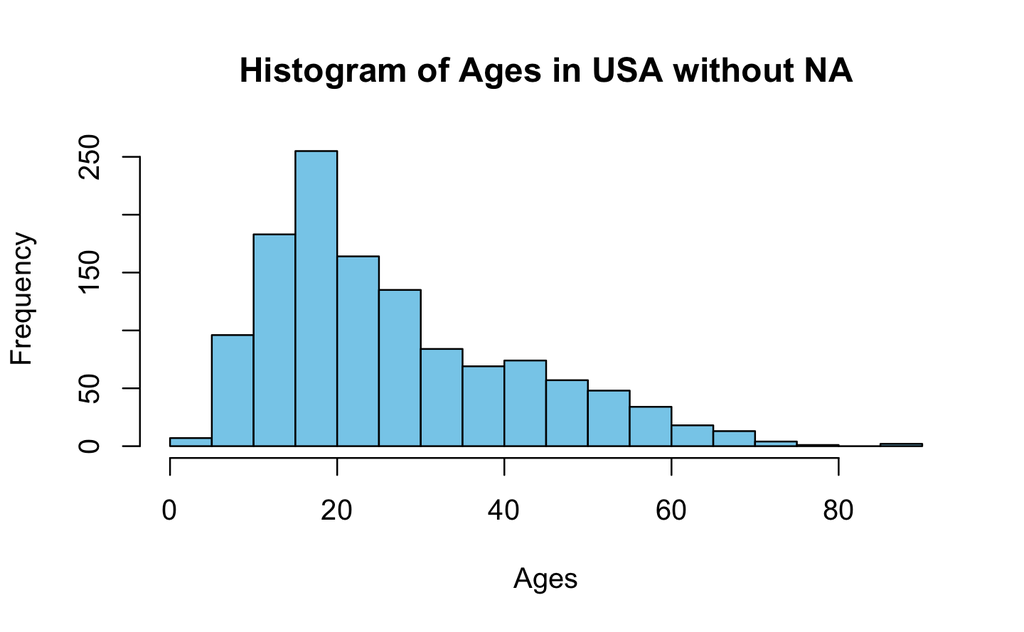

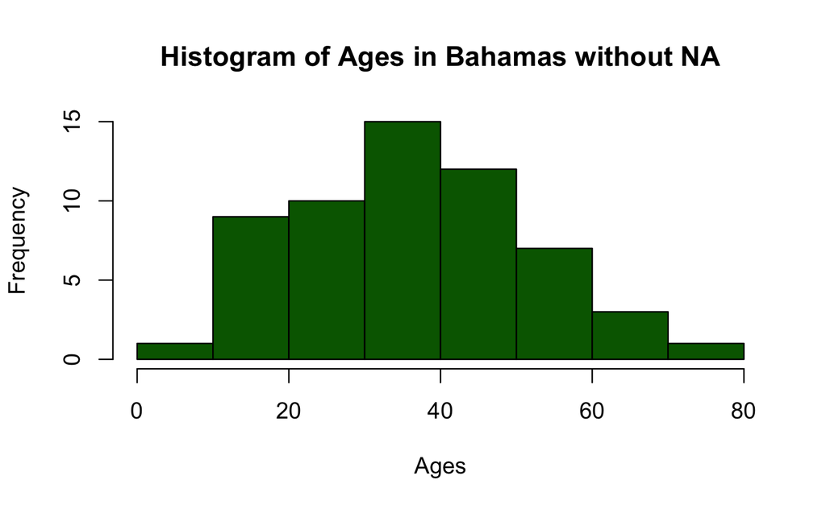

```r
#EGYPT#

ages_in_egy <- attacks %>%
  filter(Country == "EGYPT") %>%
  select(Age)

ages_vector <- ages_in_egy$Age

ages_without_na = na.omit(ages_vector)
ages_without_na <- as.numeric(ages_without_na)
#hist(ages_without_na) -> We put this function preceded by an hashtag because we do not want the histogram to be displayed for all countries
mean_egy = mean(ages_without_na)

attacks$Age[attacks$Country == "EGYPT" & is.na(attacks$Age)] <- mean_egy


#ITALY#

# Extract all ages from individuals who come from Italy
ages_in_italy <- attacks %>%
  filter(Country == "ITALY") %>%
  select(Age)

# Convert the extracted ages to a vector
ages_vector <- ages_in_italy$Age


# Display or use the 'ages_vector' containing ages from individuals in Italy

ages_without_na = na.omit(ages_vector)
ages_without_na <- as.numeric(ages_without_na)
#hist(ages_without_na) -> We put this function preceded by an hashtag because we do not want the histogram to be displayed for all countries
mean_age = mean(ages_without_na)

# Replace all the NA on Italy with the mean of people attacked in Italy.

attacks$Age[attacks$Country == "ITALY" & is.na(attacks$Age)] <- 37.375

#AUSTRALIA#

ages_in_aus <- attacks %>%
  filter(Country == "AUSTRALIA") %>%
  select(Age)

ages_vector <- ages_in_aus$Age

ages_without_na = na.omit(ages_vector)
ages_without_na <- as.numeric(ages_without_na)
#hist(ages_without_na) -> We put this function preceded by an hashtag because we do not want the histogram to be displayed for all countries
mean_aus = mean(ages_without_na)

attacks$Age[attacks$Country == "AUSTRALIA" & is.na(attacks$Age)] <- mean_aus



#SOUTH AFRICA#

ages_in_SA <- attacks %>%
  filter(Country == "SOUTH AFRICA") %>%
  select(Age)

ages_vector <- ages_in_SA$Age

ages_without_na = na.omit(ages_vector)
ages_without_na <- as.numeric(ages_without_na)
#hist(ages_without_na) -> We put this function preceded by an hashtag because we do not want the histogram to be displayed for all countries
mean_SA = mean(ages_without_na)

attacks$Age[attacks$Country == "SOUTH AFRICA" & is.na(attacks$Age)] <- mean_SA


#BRAZIL#

ages_in_BRA <- attacks %>%
  filter(Country == "BRAZIL") %>%
  select(Age)

ages_vector <- ages_in_BRA$Age

ages_without_na = na.omit(ages_vector)
ages_without_na <- as.numeric(ages_without_na)
#hist(ages_without_na) -> We put this function preceded by an hashtag because we do not want the histogram to be displayed for all countries
mean_BRA = mean(ages_without_na)

attacks$Age[attacks$Country == "BRAZIL" & is.na(attacks$Age)] <- mean_BRA


#FIJI#

ages <- attacks %>%
  filter(Country == "FIJI") %>%
  select(Age)

ages_vector <- ages$Age

ages_without_na = na.omit(ages_vector)
ages_without_na <- as.numeric(ages_without_na)
#hist(ages_without_na) -> We put this function preceded by an hashtag because we do not want the histogram to be displayed for all countries
mean = mean(ages_without_na)

attacks$Age[attacks$Country == "FIJI" & is.na(attacks$Age)] <- mean

#FRENCH POLYNESIA#

ages <- attacks %>%
  filter(Country == "FRENCH POLYNESIA") %>%
  select(Age)

ages_vector <- ages$Age

ages_without_na = na.omit(ages_vector)
ages_without_na <- as.numeric(ages_without_na)
#hist(ages_without_na) -> We put this function preceded by an hashtag because we do not want the histogram to be displayed for all countries
mean = mean(ages_without_na)

attacks$Age[attacks$Country == "FRENCH POLYNESIA" & is.na(attacks$Age)] <- mean

#HONG KONG#

ages <- attacks %>%
  filter(Country == "HONG KONG") %>%
  select(Age)

ages_vector <- ages$Age

ages_without_na = na.omit(ages_vector)
ages_without_na <- as.numeric(ages_without_na)
#hist(ages_without_na) -> We put this function preceded by an hashtag because we do not want the histogram to be displayed for all countries
mean = mean(ages_without_na)

attacks$Age[attacks$Country == "HONG KONG" & is.na(attacks$Age)] <- mean

#JAPAN#

ages <- attacks %>%
  filter(Country == "JAPAN") %>%
  select(Age)

ages_vector <- ages$Age

ages_without_na = na.omit(ages_vector)
ages_without_na <- as.numeric(ages_without_na)
#hist(ages_without_na) -> We put this function preceded by an hashtag because we do not want the histogram to be displayed for all countries
mean = mean(ages_without_na)

attacks$Age[attacks$Country == "JAPAN" & is.na(attacks$Age)] <- mean

#MEXICO#

ages <- attacks %>%
  filter(Country == "MEXICO") %>%
  select(Age)

ages_vector <- ages$Age

ages_without_na = na.omit(ages_vector)
ages_without_na <- as.numeric(ages_without_na)
#hist(ages_without_na) -> We put this function preceded by an hashtag because we do not want the histogram to be displayed for all countries
mean = mean(ages_without_na)

attacks$Age[attacks$Country == "MEXICO" & is.na(attacks$Age)] <- mean


#MOZAMBIQUE#

ages <- attacks %>%
  filter(Country == "MOZAMBIQUE") %>%
  select(Age)

ages_vector <- ages$Age

ages_without_na = na.omit(ages_vector)
ages_without_na <- as.numeric(ages_without_na)
#hist(ages_without_na) -> We put this function preceded by an hashtag because we do not want the histogram to be displayed for all countries
mean = mean(ages_without_na)

attacks$Age[attacks$Country == "MOZAMBIQUE" & is.na(attacks$Age)] <- mean


#NEW ZELAND#

ages <- attacks %>%
  filter(Country == "NEW ZEALAND") %>%
  select(Age)

ages_vector <- ages$Age

ages_without_na = na.omit(ages_vector)
ages_without_na <- as.numeric(ages_without_na)
#hist(ages_without_na) -> We put this function preceded by an hashtag because we do not want the histogram to be displayed for all countries
mean = mean(ages_without_na)

attacks$Age[attacks$Country == "NEW ZEALAND" & is.na(attacks$Age)] <- mean

#PHILIPPINES#

ages <- attacks %>%
  filter(Country == "PHILIPPINES") %>%
  select(Age)

ages_vector <- ages$Age

ages_without_na = na.omit(ages_vector)
ages_without_na <- as.numeric(ages_without_na)
#hist(ages_without_na) -> We put this function preceded by an hashtag because we do not want the histogram to be displayed for all countries
mean = mean(ages_without_na)

attacks$Age[attacks$Country == "PHILIPPINES" & is.na(attacks$Age)] <- mean
```

```r
#REUNION#

ages <- attacks %>%
  filter(Country == "REUNION") %>%
  select(Age)

ages_vector <- ages$Age

ages_without_na = na.omit(ages_vector)
ages_without_na <- as.numeric(ages_without_na)
#hist(ages_without_na) -> We put this function preceded by an hashtag because we do not want the histogram to be displayed for all countries
mean = mean(ages_without_na)

attacks$Age[attacks$Country == "REUNION" & is.na(attacks$Age)] <- mean

#NEW CALEDONIA#

ages <- attacks %>%
  filter(Country == "NEW CALEDONIA") %>%
  select(Age)

ages_vector <- ages$Age

ages_without_na = na.omit(ages_vector)
ages_without_na <- as.numeric(ages_without_na)
#hist(ages_without_na) -> We put this function preceded by an hashtag because we do not want the histogram to be displayed for all countries
mean = mean(ages_without_na)

attacks$Age[attacks$Country == "NEW CALEDONIA" & is.na(attacks$Age)] <- mean


#We fixed those countries that had lots of NA. Now, for the remaining NA we decided not to do anything for a specific reason. Not only we have not cound the real information on the internet, but we also believe that doing the mean for those remaining situations was useless, because these are the cases when NA are either the same amount of total shark attacks (see Antigua with 1 shark attack and 1 NA), or NA are more than half of the total attacks (see Malaysia with 4 total attacks but 3 of them are NA).


count_na_by_country <- attacks %>%
  group_by(Country) %>%
  summarise(NA_count = sum(is.na(Age)))


attacks <- subset(attacks, !is.na(Age))

#___________________________________________________________________________________________________________________


#NOW WORK ON TIME

#sometimes hours are written in a different format compared to most of the others, which follow the format
#13h30. Since they are not a lot we just replaced them manually

attacks<- mutate(attacks, Time= ifelse(Time=="Possibly same incident as 2000.08.21", "", Time))
attacks<- mutate(attacks, Time= ifelse(Time=="14h00  -15h00", "14h30", Time))
attacks<- mutate(attacks, Time= ifelse(Time=="14h30 / 15h30", "15h00", Time))
attacks<- mutate(attacks, Time= ifelse(Time=="09h30 / 10h00", "9h45", Time))
attacks<- mutate(attacks, Time= ifelse(Time=="10h45-11h15", "11h00", Time))
attacks<- mutate(attacks, Time= ifelse(Time=="Sometime between 06h00 & 08hoo", "7h00", Time))
attacks<- mutate(attacks, Time= ifelse(Time=="18h15-18h30", "18h20", Time))
attacks<- mutate(attacks, Time= ifelse(Time=="09h00 - 09h30", "9h15", Time))
attacks<- mutate(attacks, Time= ifelse(Time=="10h00 -- 11h00", "10h30", Time))
attacks<- mutate(attacks, Time= ifelse(Time=="11h115", "11h15", Time))
attacks <- mutate(attacks, Time = ifelse(Time == "Between 05h00 and 08h00", "6h30", Time))
attacks <- mutate(attacks, Time = ifelse(Time == "17h00 or 17h40", "17h20", Time))
attacks <- mutate(attacks, Time = ifelse(Time == "13h345", "13h45", Time))
attacks <- mutate(attacks, Time = ifelse(Time == "<a0> ", "", Time))
attacks <- mutate(attacks, Time = ifelse(Time == "09h00 -10h00", "9h30", Time))
attacks <- mutate(attacks, Time = ifelse(Time == "2 hours after Opperman", "", Time))
attacks <- mutate(attacks, Time = ifelse(Time == "11h00 / 11h30", "11h15", Time))
attacks <- mutate(attacks, Time = ifelse(Time == "Between 06h00 & 07h20", "6h40", Time))
attacks <- mutate(attacks, Time = ifelse(Time == "30 minutes after 1992.07.08.a", "", Time))



#now, our objective is to classify hours in parts of the day. indeed, it is useless to keep hours as they are
#for a regression because we want times like 7h30 and 7h00 OR 15h00 and 16h00 to be read as the same thing.
# some of the rows already had the part of the day in it, but in order to work easily with all the column, we
#replaced "morning" with 8h00 etc. in this way, we're able to remove all the strings that are useless. finally,
#void rows have been replaced by an NA and hours, which were there as CHAR have been replaced by numeric

attacks$Time <- str_replace_all(attacks$Time, "\\bmorning\\b", "8h00")
attacks$Time <- str_replace_all(attacks$Time, "\\bafternoon\\b", "15h00")
attacks$Time <- str_replace_all(attacks$Time, "\\bevening\\b", "20h00")
attacks$Time <- str_replace_all(attacks$Time, "\\bnight\\b", "23h00")

attacks$Time <- gsub("[^[:digit:]]", "", attacks$Time)
attacks$Time = na_if(attacks$Time, "")
attacks$Time <- as.numeric(attacks$Time)

# since we removed all the letters, hours now are not written as 8h00 or 15h30 but as 800 and 15h00. this is
# great for us, so that we can easily create a function that classifies those numbers as parts of the day. the
#function works this way: if a value is included between 0 and 500 (i.e. midnight and 5a.m.), the value is replaced
#by the word "night" etc.

timeoftheday <- function(time) {
  if (!is.na(time)) {
    if (time >= 0 && time < 500) {
      return("night")
    } else if (time >= 500 && time < 1200) {
      return("morning")
    } else if (time >= 1200 && time < 1730) {
      return("afternoon")
    } else if (time >= 1730 && time < 2400) {
      return("evening")
    } else {
      return("")  # Handle any other cases (if necessary)
    }
  } else {
    return(NA)  # Retain NA values
  }
}

attacks$Time <- sapply(attacks$Time, timeoftheday)
attacks$Time <- tolower(attacks$Time)
attacks$Time <- na_if(attacks$Time, "")


sum(is.na(attacks$Time)) #this is the only one that still presents 1415 NA. we dont want to delete
#them all coz we'd lose 44% of our data.
table(attacks$Time)#table shows that most of them happen in the afternoon, while 2ns place is owned by
#morning. To confirm the higher frequency of attacks between 8am and 6pm is this artile (link JC found??)
#we explain this by the fact that, naturally, most of people swim during the day. therefore, what we do
#is replacing NA randomly by the proportion of afternoon, morning and evening.

sum(!is.na(attacks$Time))

#create function that substitutes the NA in time with one of the 4 parts of the day, based on their
#proportion presence in our dataset
```

```r
non_na_time_proportions <- table(attacks$Time) / sum(!is.na(attacks$Time))


# Identify NA positions
position_of_na <- is.na(attacks$Time)

# Generate random values based on proportions
attacks$Time[position_of_na] <- sample(
  names(non_na_time_proportions),
  sum(position_of_na),
  replace = TRUE,
  prob = as.vector(non_na_time_proportions)
)


#_____________________________________________________________________________________________
#NOW WE WORK ON SEX

attacks$Sex <- gsub("lli", "", attacks$Sex)
attacks$Sex <- gsub("M ", "M", attacks$Sex)
attacks$Sex <- na_if(attacks$Sex, "")
attacks$Sex <- ifelse(is.na(attacks$Sex), "Unknown", attacks$Sex)

#__________________________________________________________________________________________________________________


#NOW WE WORK ON SHARK SPECIES


#Creation of a variable species where we delete all the numbers that concern the size of the shark
attacks$Species <- str_remove_all(attacks$Species, "[[:digit:]]")

#If there is an empty cell, we will put NA
species = na_if(attacks$Species, "")

#gsub to take off punctuation
species <- gsub("[[:punct:]]", "", species)

#Delete all the numbers followed by cm or m
species <- gsub("\\d+\\s*(cm|m)\\b", "", species)

#Delete word composed by 1 or 2 letters
species <- gsub("\\b\\w{1,2}\\b", "", species)

#Delete all the numbers
species <- gsub("\\d", "", species)

#Delete all unities as lb, kg or l
species <- gsub("\\b(kg|lb|b)\\b", "", species)

#If the word shark appears more than once in each cell, we only write shark once
species <- gsub("\\bshark\\b(.*\\bshark\\b)?", "shark", species, ignore.case = TRUE)


# Rewrite shark species names in one way, and do that for each species
species<- gsub("^.*White shark.*$", "White shark", species)
species<- gsub("^.*whitetip shark.*$", "White shark", species)
species<- gsub("^.*white shark.*$", "White shark", species)
species<- gsub("^.*Wobbegong shark.*$", "Wobbegong shark", species)
species<- gsub("^.*Wobbegong.*$", "Wobbegong shark", species)
species<- gsub("^.*Zambesi shark.*$", "Zambesi shark", species)
species<- gsub("^.*Zambezi shark.*$", "Zambesi shark", species)
species<- gsub("^.*whaler shark.*$", "Whale shark", species)
species<- gsub("^.*whale shark.*$", "Whale shark", species)
species<- gsub("^.*tiger shark.*$", "Tiger shark", species)
species<- gsub("^.*Tiger shark.*$", "Tiger shark", species)
species<- gsub("^.*thresher shark.*$", "Thresher shark", species)
species<- gsub("^.*spinner shark.*$", "Spinner shark", species)
species<- gsub("^.*Spinner shark feet.*$", "Spinner shark", species)
species<- gsub("^.*Spinner shark.*$", "Spinner shark", species)
species<- gsub("^.*spinner  blacktip shark.*$", "Spinner shark", species)
species<- gsub("^.*Tawny nurse shark.*$", "Nurse shark", species)
species<- gsub("^.*nurse shark.*$", "Nurse shark", species)
species<- gsub("^.*Nurse shark.*$", "Nurse shark", species)
species<- gsub("^.*Mako shark.*$", "Mako shark", species)
species<- gsub("^.*mako shark.*$", "Mako shark", species)
species<- gsub("^.*Lemon shark.*$", "Lemon shark", species)
species<- gsub(".*lemon shark.*", "Lemon shark", species, ignore.case = TRUE)
species<-gsub("^\\s*shark\\s*$", "Unidentified shark", species)
species<- gsub(".*bull.*", "Bull shark", species, ignore.case = TRUE)
species<- gsub(".*blue.*", "Blue shark", species, ignore.case = TRUE)
species<- gsub(".*reef.*", "Reef shark", species, ignore.case = TRUE)
species<- gsub(".*sand shark*", "Sand shark", species, ignore.case = TRUE)
species<- gsub("^.*Sand shark.*$", "Sand shark", species)
species<- gsub(".*Sand shark*", "Sand shark", species, ignore.case = TRUE)
species<- gsub(".*sandshark*", "Sand shark", species, ignore.case = TRUE)
species<- gsub(".*Sandbar shark*", "Sand shark", species, ignore.case = TRUE)
species<- gsub("juvenile\\s+\\w+", "Juvenile shark",species, ignore.case = TRUE)
species<- gsub("Juvenile shark shark", "Juvenile shark",species, ignore.case = TRUE)
species<- gsub("Juvenile shark  blacktip shark", "Juvenile shark",species, ignore.case = TRUE)
species<- gsub("blacktip\\s+\\w+", "Blacktip shark",species, ignore.case = TRUE)
species <- gsub("\\black\\w*\\b", "Blacktip shark", species, ignore.case = TRUE)

#Replace all occurrences of the word "blacktip" in a column with "Blacktip Shark," even if the word is accompanied by other words before or after

species <- gsub("\\bblacktip\\b", "Blacktip Shark", species, ignore.case = TRUE)
species<- gsub(".*copper shark*", "Copper shark", species, ignore.case = TRUE)
species <- gsub("\\bcow\\b", "Cow", species)
species <- gsub("\\bsilky\\b", "Silky", species)
species <- gsub("\\bsilvertip\\b", "Silvertip", species)


#Condition: if "Hammerhead" followed by other words then replaced by Hammerhead shark
species <- ifelse(grepl("Hammerhead\\s+\\w+", species, ignore.case = TRUE), "Hammerhead shark", species)
species <- ifelse(grepl("Blacktip\\s+\\w+", species, ignore.case = TRUE), "Blacktip shark", species)
species <- ifelse(grepl("Raggedtooth\\s+\\w+", species, ignore.case = TRUE), "Raggedtooth shark", species)
species <- ifelse(grepl("Porbeagle\\s+\\w+", species, ignore.case = TRUE), "Porbeagle shark", species)


#if the word shark does not appear then NA
species <- ifelse(grepl("shark", species, ignore.case = TRUE), species, NA)
species <- ifelse(grepl("Juvenile\\s+\\w+", species, ignore.case = TRUE), "Juvenile shark", species)
species <- ifelse(grepl("grey\\s+\\w+", species, ignore.case = TRUE), "Grey shark", species)
species <- ifelse(grepl("greycolored\\s+\\w+", species, ignore.case = TRUE), "Grey shark", species)
species <- ifelse(grepl("gray\\s+\\w+", species, ignore.case = TRUE), "Grey shark", species)
species <- ifelse(grepl("Broadnose\\s+\\w+", species, ignore.case = TRUE), "Sevengill shark", species)
species <- ifelse(grepl("7gill\\s+\\w+", species, ignore.case = TRUE), "Sevengill shark", species)
species <- ifelse(grepl("sevengill\\s+\\w+", species, ignore.case = TRUE), "Sevengill shark", species)
species <- ifelse(grepl("black\\s+\\w+", species, ignore.case = TRUE), "Blacktip shark", species)
species <- ifelse(grepl("Sand\\s+\\w+", species, ignore.case = TRUE), "Sand shark", species)
species <- ifelse(grepl("Carpet\\s+\\w+", species, ignore.case = TRUE), "Carpet shark", species)
species <- ifelse(grepl("\\bbrown\\b", species, ignore.case = TRUE), "Brown shark", species)
```

```r
species <- gsub("^frag\\w+", "Unidentified shark", species)
species <- gsub("^shark$", "Unidentified shark", species)

#Function to check if "small" is present in cell
contains_small <- function(text) {
  return(grepl("small", text))
}
# Replace cell with "unidentified shark" if "small" is present
species <- ifelse(sapply(species, contains_small), "Unidentified shark", species)

#Function to check if "Small" is present in cell
contains_small <- function(text) {
  return(grepl("Small", text))
}
#  Replace cell with "unidentified shark" if "Small" is present
species <- ifelse(sapply(species, contains_small), "Unidentified shark", species)

#Function to check if "sharks" is present in cell
contains_sharks <- function(text) {
  return(grepl("sharks", text))
}
# Replace cell with"unidentified shark" if "sharks" is present
species <- ifelse(sapply(species, contains_sharks), "Unidentified shark", species)

#Function to check if "cookie" is present in cell
contains_cookie <- function(text) {
  return(grepl("cookie", text))
}
# Replace cell with"Cookiecutter shark" if "cookie" is present
species <- ifelse(sapply(species, contains_cookie), "Cookiecutter shark", species)


#Function to check if "involvement" is present in cell
contains_involvement <- function(text) {
  return(grepl("involvement", text))
}
# Replace cell with"No shark" if "involvement" is present
species <- ifelse(sapply(species, contains_involvement), "No shark", species)

#Function to check if "invovlement" is present in cell
contains_invovlement <- function(text) {
  return(grepl("invovlement", text))
}
# Replace cell with"No shark" if "invovlement" is present
species <- ifelse(sapply(species, contains_invovlement), "No shark", species)

#Function to check if "Not" is present in cell
contains_Not <- function(text) {
  return(grepl("Not", text))
}
# Replace cell with"No shark" if "Not" is present
species <- ifelse(sapply(species, contains_Not), "No shark", species)

#Function to check if "not" is present in cell
contains_not <- function(text) {
  return(grepl("not", text))
}
# Replace cell with"No shark" if "not" is present
species <- ifelse(sapply(species, contains_not), "No shark", species)

#Function to check if "Questionable" is present in cell
contains_Questionable <- function(text) {
  return(grepl("Questionable", text))
}
# Replace cell with"No shark" if "Questionable" is present
species <- ifelse(sapply(species, contains_Questionable), "No shark", species)

#Function to check if "questionable" is present in cell
contains_questionable <- function(text) {
  return(grepl("questionable", text))
}
# Replace cell with"No shark" if "questionable" is present
species <- ifelse(sapply(species, contains_questionable), "No shark", species)


#Function to check if "Salmon" is present in cell
contains_Salmon <- function(text) {
  return(grepl("Salmon", text))
}
# Replace cell with"Salmon shark" if "Salmon" is present
species <- ifelse(sapply(species, contains_Salmon), "Salmon shark", species)


#Function to check if "whaler" is present in cell
contains_whaler <- function(text) {
  return(grepl("whaler", text))
}
# Replace cell with"Whale shark" if "involvement" is present
species <- ifelse(sapply(species, contains_whaler), "Whale shark", species)


# Replace the cell with "Unidentified shark" if any of the specified words are found
species <- ifelse(grepl("(seen|observed|Tooth|tooth|large|killed|captive|female|metre|foot|followed|caused|Said|young|probably|gaffed)", species, ignore.case = TRUE), "Unidentified shark", species)

# Replace the cell with "No shark" if any of the specified words are found
species <- ifelse(grepl("(hoax|No Shark)", species, ignore.case = TRUE), "No shark", species)

# Replace the cell with "Copper shark" if any of the specified words are found
species <- ifelse(grepl("(Copper)", species, ignore.case = TRUE), "Copper shark", species)

# Replace the cell with "Dogfish shark" if any of the specified words are found
species <- ifelse(grepl("(Dog|dogfish)", species, ignore.case = TRUE), "Dogfish shark", species)

# Replace the cell with "Dusky shark" if any of the specified words are found
species <- ifelse(grepl("(Dusky)", species, ignore.case = TRUE), "Dusky shark", species)

# Replace the cell with "Sevengill shark" if any of the specified words are found
species <- ifelse(grepl("(gill)", species, ignore.case = TRUE), "Sevengill shark", species)

# Replace the cell with "Angel shark" if any of the specified words are found
species <- ifelse(grepl("(Angel)", species, ignore.case = TRUE), "Angel shark", species)


attacks$Species <- species
attacks$Species <- ifelse(is.na(attacks$Species), "Unidentifies shark", attacks$Species)

#_____________________________________________________________________________________________

#ACTIVITY

#when trying to put everything in lower cap, this was the result: Errore in tolower(attacks$Activity) :  multibyte string 921 not valid --> therefore, we converted everything in ASCII (=American Standard Code for Information Interchange)

attacks$Activity <- iconv(attacks$Activity, to = "ASCII", sub = " ")
attacks$Activity <- gsub("[^ -~]", "", attacks$Activity)

attacks$Activity <- tolower(attacks$Activity)

#when running a table of all activities, we can see that we can group them in some categories: diving, race, windsurfing, walking, wading, wade fishing, touching, swimming, surfing, surf, standing, spearfishing, snorkeling,  scuba diving, playing, paddle, murder, kayaking, kayak, floating, fishing, so that we have standard categories.

attacks$Activity <- gsub("[^A-Za-z ]", "", attacks$Activity)


kept_activities <- c("diving", "race", "windsurfing", "walking", "wading", "wade fishing", "touching", "swimming", "surfing", "surf", "standing", "spearfishing", "snorkeling", "scuba diving", "playing", "paddle", "murder", "kayaking", "kayak", "floating", "fishing")


# We create an expression pattern that matches any of the specific words
pattern <- paste(kept_activities, collapse = "|")
```

```r
# Extract only the specific words (kept_activities) from the column and replace the rest with an empty string
attacks$Activity <- str_extract(attacks$Activity, paste0("\\b(?:", pattern, ")\\b"))

attacks <- attacks %>%
  mutate(Activity = str_replace_all(Activity, "\\bkayaking\\b", "kayak")) %>%
  mutate(Activity = str_replace_all(Activity, "\\bsurfing\\b", "surf"))

attacks$Activity[is.na(attacks$Activity)] <- "other" # for all activities that are not part of the list or for NA, we just put Other, since no information is available


#_____________________________________________________________________________________________

#FATAL
 #When we run a table for the Fatality column, we see that almost observation follow the same category (Y = yes, N = No, Unknwn). An observation has a 2017, which is probably a typo (which we replace by empty case) while another one has an M. We want to believe that it was a typo as well, and that "M" was typed instead of "N".
attacks$Fatal..Y.N. <- gsub("2017", "", attacks$Fatal..Y.N.)
attacks$Fatal..Y.N. <- gsub("M", "N", attacks$Fatal..Y.N.)

attacks$Fatal..Y.N. <-na_if(attacks$Fatal..Y.N., "")

#For the rest of NA, we have no information, so we took of these few observations.
attacks <- subset(attacks, !is.na(Fatal..Y.N.))
#Replace Yes by 1, 0 otherwise
attacks$Fatal..Y.N. <- ifelse(attacks$Fatal..Y.N. == "Y", 1, 0)

names(attacks)[names(attacks) == "Fatal..Y.N."] <- "Fatality"


#_____________________________________________________________________________________________
#final check up:

#We run a table for all columns, in order to check if columns have any missing value or if we still have other mistakes.

table(attacks$Date) #this one is fine
table(attacks$Year) #this one is fine
table(attacks$Type) #here we have boating and boat which mean the same thing. Let us group them
attacks$Type <- gsub("Boating", "Boat", attacks$Type)
attacks$Type <- gsub("Boatomg", "Boat", attacks$Type)
table(attacks$Type) #this one is fine
table(attacks$Country)#this one is fine
table(attacks$Activity)#this one is fine
table(attacks$Age)#this one is fine
table(attacks$Fatality)#this one is fine
table(attacks$Species)#this one is fine


#With the following code, we will add a new column which will associate each country with its ISO code. This is a very important step for the cleaning if the enxt sections, because il will allow us to match the different datasets.

# Get ISO country codes
iso_codes <- countrycode(attacks$Country, "country.name", "iso3c")
attacks$ISO_Code <- countrycode(attacks$Country, "country.name", "iso3c")

#Through the following function we can spot NAs. We can see that there are 23 countries with no ISO Code. We will fix them by hand.
rows_with_na <- which(is.na(attacks$ISO_Code))

attacks$ISO_Code[attacks$Country %in% c("ENGLAND", "SCOTLAND", "BRITISH ISLES") & is.na(attacks$ISO_Code)] <- "GB"
attacks$ISO_Code[attacks$Country %in% c("AZORES") & is.na(attacks$ISO_Code)] <- "PRT"
attacks$ISO_Code[attacks$Country %in% c("ST. MAARTIN", "ST. MARTIN") & is.na(attacks$ISO_Code)] <- "MAF"
attacks$ISO_Code[attacks$Country %in% c("OKINAWA") & is.na(attacks$ISO_Code)] <- "JPN"
attacks$ISO_Code[attacks$Country %in% c("MICRONESIA") & is.na(attacks$ISO_Code)] <- "FSM"
attacks <- subset(attacks, !is.na(ISO_Code))
```

```r
DT::datatable(attacks, options = list(pageLength = 10))
```

|  | Case.Number | Date | Year | Type | Country | Activity | Sex | Age | Fatality | Time | Species | ISO_Code |
| --- | --- | --- | --- | --- | --- | --- | --- | --- | --- | --- | --- | --- |
| 1 | 2018.06.25 | 6 | 2018 | Boat | USA | other | F | 57 | 0 | evening | White shark | USA |
| 2 | 2018.06.18 | 6 | 2018 | Unprovoked | USA | standing | F | 11 | 0 | afternoon | Unidentifies shark | USA |
| 3 | 2018.06.09 | 6 | 2018 | Invalid | USA | surf | M | 48 | 0 | morning | Unidentifies shark | USA |
| 4 | 2018.06.08 | 6 | 2018 | Unprovoked | AUSTRALIA | surf | M | 31.30226700251889 | 0 | morning | Unidentified shark | AUS |
| 5 | 2018.06.04 | 6 | 2018 | Provoked | MEXICO | diving | M | 32.44827586206897 | 0 | afternoon | Tiger shark | MEX |
| 6 | 2018.06.03.b | 6 | 2018 | Unprovoked | AUSTRALIA | surf | M | 31.30226700251889 | 0 | afternoon | Unidentifies shark | AUS |
| 7 | 2018.06.03.a | 6 | 2018 | Unprovoked | BRAZIL | swimming | M | 18 | 1 | afternoon | Tiger shark | BRA |
| 8 | 2018.05.27 | 5 | 2018 | Unprovoked | USA | fishing | M | 52 | 0 | evening | Lemon shark | USA |
| 9 | 2018.05.26.b | 5 | 2018 | Unprovoked | USA | walking | M | 15 | 0 | afternoon | Bull shark | USA |
| 10 | 2018.05.26.a | 5 | 2018 | Unprovoked | USA | standing | M | 12 | 0 | afternoon | Unidentifies shark | USA |

[output cut: 2965 more lines]

## 3.2 Temperatures Cleaning

The main mission for this dataset was to change the entire structure of the dataset. Originally, the dataset had the years as columns (one column for each year), while the rows were represented by the different countries; the temperature observations were presented by month, quarter and year. Furthermore, for each country and each month/quarter/year, the dataset shows both the change in temperatures and the standard deviation.

To proceed with the cleaning, we eliminated the rows corresponding to the standard deviation (we will not work with it), and the monthly and quarterly observations: we are only interested in yearly temperature variations.

We then rotated the dataset so as to have all the years under a single column; we subsequently matched each country and year with its temperature change observation. Finally we added the ISO code to merge with the other datasets.

```r
temperature <- read_xlsx(here::here("data/Temperature.xlsx"))

#R did not read the "°C" on the column Unit, so we changed it manually

temperature <- temperature %>% mutate(Unit = "°C")

#We take off all the columns that we do not need for our study

temperature <- temperature %>% select(-'Area Code (M49)', -'Months Code', -'Element Code')

#We wliminate all columns having an F at the end (For each year there are 2 columns (ex: 1961 - 1961F; 1962 - 1962F). The column with the F at the end of the Year is a column where only the letter E appears for each row. We tried to look for its meaning on the FAO website but we did not succeed. Therefore, we removed it. What is more, it is important to notice that it was in any case unimportant for our work).

columns_to_remove <- grep("F$", names(temperature), value = TRUE)
temperature <- temperature[, !(names(temperature) %in% columns_to_remove)]

# We keep only meteorological year, we don't need to work with monthly and seasonal data.

target_name <- "Meteorological year"
temperature <- temperature[temperature$Months == target_name, ]

target_name2 <- "Temperature change"
temperature <- temperature[temperature$Element == target_name2, ]



#  We take off the rest of the columns that we do not need

temperature <- temperature %>% select(-'Area Code', -'Months', -'Element', -'Unit')

#The column of each year starts with an Y (Y1961, Y1961...). We take it off, so that we can easily match data with other datasets.

new_colnames <- gsub("Y", "", colnames(temperature))
colnames(temperature) <- new_colnames
temperature <- na.omit(temperature)


# We transpose the dataset so that columns become rows. With this function we have a single column, where each row corresponds to a year, but countries became the columns now. We will work on this later in the code.
temperature <- t(temperature)

# I want the first row to be the header

colnames(temperature) <- temperature[1, ]
clean_temperature <- temperature[-1, ]

#col names in CAPS
colnames(clean_temperature) <- toupper(colnames(clean_temperature))


library(tidyr)

# Convert the matrix/array "clean_temperatures" to a data frame
temperature <- as.data.frame(clean_temperature)

# Add 'Year' as a separate column
temperature$Year <- rownames(clean_temperature)

# Reshape the data from wide to long format
temperature <- tidyr::pivot_longer(temperature,
                                     cols = -Year,
                                     names_to = "Country",
                                     values_to = "Temperature")

# Reorder columns as per your desired format
temperature <- temperature[c("Year", "Country", "Temperature")]

#As we said at the beginning, we only work with data from 1970
temperature <- temperature %>% filter(Year >= 1970)
temperature$Year <- as.numeric(temperature$Year)

temperature <- temperature %>%
  mutate(Country = ifelse(Country == "UNITED STATES OF AMERICA", "USA", Country))

#As for the attacks dataset, we add a column for the ISO code.

temperature$ISO_Code <- countrycode(temperature$Country, "country.name", "iso3c")
temperature$ISO_Code[temperature$Country %in% c("MICRONESIA") & is.na(temperature$ISO_Code)] <- "FSM"

#Now that we put ISO code, we can remove the country column
temperature <- temperature %>% select(-'Country')

DT::datatable(temperature, options = list(pageLength = 10))
```

|  | Year | Temperature | ISO_Code |
| --- | --- | --- | --- |
| 1 | 1970 | 0.813 | AFG |
| 2 | 1970 | -0.106 | ALB |
| 3 | 1970 | 0.116 | DZA |
| 4 | 1970 | 0.121 | AND |
| 5 | 1970 | 0.248 | AGO |
| 6 | 1970 | 0.082 | AIA |
| 7 | 1970 | -0.133 | ATA |
| 8 | 1970 | 0.438 | ARG |
| 9 | 1970 | -0.007 | AUS |
| 10 | 1970 | -0.550 | AUT |

[output cut: 10696 more lines]

## 3.3 Sea Level Cleaning

We choose a data set about the sea level change observed during the last years. We start analyzing the sea level changes since 1993 because we did not find any data of years before. In this data set we had few columns but we only kept 2 columns that were the more relevant for us: the year and the GMSL_GIA. This last column is the global mean of sea level including the glacial isostatic adjustement (GIA). We choose the column with GIA and not without because this show the response of solid Earth to the past changes in surface loading by ice and water such as the glaciation and deglaciation.

```r
sealevel <- read.csv(here::here("data/sealevel.csv"))

# keep the 2 columns we are interested to analyze because the other are irrelevant for our project
sealevel <- subset(sealevel, select = c(Year, GMSL_GIA))

#Show the year only the first time by creating a new column called Year2
sealevel$Year2 <- ifelse(duplicated(sealevel$Year), NA, sealevel$Year)

# delete column Year due to the creation of column Year 2
sealevel <- subset(sealevel, select = -Year)

# delete NA because it does not bring anything to our analysis
sealevel <- na.omit(sealevel)

#Change name of column Year
column <- gsub("2","",colnames(sealevel))
colnames(sealevel) <- column

DT::datatable(sealevel, options = list(pageLength = 10))
```

|  | GMSL_GIA | Year |
| --- | --- | --- |
| 1 | -38.59 | 1993 |
| 38 | -33.08 | 1994 |
| 75 | -24.23 | 1995 |
| 112 | -29.84 | 1996 |
| 148 | -28.52 | 1997 |
| 185 | -23.25 | 1998 |
| 222 | -26.81 | 1999 |
| 259 | -17.98 | 2000 |
| 296 | -15.14 | 2001 |
| 333 | -13.55 | 2002 |

[output cut: 19 more lines]

## 3.4 Greenhouse Gas Emissions Cleaning

Finally, the GHG emissions dataset was the easiest to clean. Indeed, we already have a column for the ISO code, so we simply had to filter the years so that the observations began in 1970.

```r
co2 <- read.csv(here::here("data/CO2.csv"))

# Change names of columns in order to have the same columns that in the other datasets
names(co2)[names(co2) == "Entity"] <- "Country"
names(co2)[names(co2) == "Annual.CO..emissions"] <- "Annual CO2 Emissions"
names(co2)[names(co2) == "Code"] <- "ISO_Code"



# keep the 3 columns we are interested to analyze
co2 <- subset(co2, select = c("ISO_Code", "Year", "Annual CO2 Emissions"))


# only keep information starting in 1970 because we want to look at the evolution of
# the last 50 years
co2<- co2[co2$Year >= 1970, ]

co2$ISO_Code <- na_if(co2$ISO_Code, "")

co2 <- subset(co2, !is.na(ISO_Code))

DT::datatable(co2, options = list(pageLength = 10))
```

|  | ISO_Code | Year | Annual CO2 Emissions |
| --- | --- | --- | --- |
| 22 | AFG | 1970 | 1670397 |
| 23 | AFG | 1971 | 1893554 |
| 24 | AFG | 1972 | 1530347 |
| 25 | AFG | 1973 | 1635454 |
| 26 | AFG | 1974 | 1913152 |
| 27 | AFG | 1975 | 2121383 |
| 28 | AFG | 1976 | 1980859 |
| 29 | AFG | 1977 | 2384175 |
| 30 | AFG | 1978 | 2153300 |
| 31 | AFG | 1979 | 2232754 |

[output cut: 11164 more lines]

## 3.5 Merged Data Set

After cleaning the four datasets, we have finally merged them. This step is essential to be able to run regression across variables that came from multiple datasets.

```r
#MERGE FIRST TWO DATA SETS

# Assuming 'Year' and 'Country' are the columns in both datasets for matching
merged_data <- left_join(attacks, temperature, by = c("Year", "ISO_Code"))

#MERGE WITH THIRD

# Assuming 'Year' is the columns in both datasets for matching
merged_data2 <- left_join(merged_data, sealevel, by = c("Year"))

#MERGE WITH FOURTH

# Assuming 'Year' and 'Country' are the columns in both datasets for matching
merged_data3 <- left_join(merged_data2, co2, by = c("Year", "ISO_Code"))
merged_data3$Temperature <- as.numeric(as.character(merged_data3$Temperature))
# Assuming 'Year' and 'Country' are the columns in both datasets for matching
merged_data3 <- left_join(merged_data2, co2, by = c("Year", "ISO_Code"))

#Change name of a column
colnames(merged_data3)[colnames(merged_data3) == 'Country.x'] <- 'Country'
merged_data3$Temperature <- as.numeric(merged_data3$Temperature)


#for merged_data3, which we will use for our regressions, we need numerical variables
#therefore, we will make changes in some categorical ones

#TYPE

#Let's transform the Type variable on numeric. 1 corresponds to Boat, 2 to Unprovoked, Invalid to 3
# Provoked to 4, Questionable to 5 and Sea Disaster to 6
categories <- c("Boat" = 1, "Unprovoked" = 2, "Invalid" = 3, "Provoked" = 4, "Questionable" = 5, "Sea Disaster" = 6)
merged_data3$Type <- factor(merged_data3$Type, levels = names(categories))
merged_data3$Type <- as.numeric(merged_data3$Type)

#TIME

# Let's focus on the transformation of time where morning correspond to 0, afternoon to 1,
# evening to 2 and night to 3
merged_data3$Time <- as.numeric(factor(merged_data3$Time, levels = c("morning", "afternoon", "evening", "night")))


#SEX

merged_data3$Sex <- ifelse(merged_data3$Sex == "M", 0,
                      ifelse(merged_data3$Sex == "F", 1, 2))


#SPECIES


merged_data3 <- merged_data3 %>%
  mutate(Species = as.numeric(factor(Species)))

# Get the top 5 species
top_species <- merged_data3 %>%
  count(Species, sort = TRUE) %>%
  slice_head(n = 5)

# Create a logical condition to include only the top 5 species
condition <- merged_data3$Species %in% top_species$Species

# Subset the data based on the condition
species_filtered_data <- merged_data3[condition, ]



DT::datatable(merged_data3, options = list(pageLength = 10))
```

|  | Case.Number | Date | Year | Type | Country | Activity | Sex | Age | Fatality | Time | Species | ISO_Code | Temperature | GMSL_GIA | Annual CO2 Emissions |
| --- | --- | --- | --- | --- | --- | --- | --- | --- | --- | --- | --- | --- | --- | --- | --- |
| 1 | 2018.06.25 | 6 | 2018 | 1 | USA | other | 1 | 57 | 0 | 3 | 39 | USA | 1.276 | 46.01 | 5376657400 |
| 2 | 2018.06.18 | 6 | 2018 | 2 | USA | standing | 1 | 11 | 0 | 2 | 37 | USA | 1.276 | 46.01 | 5376657400 |
| 3 | 2018.06.09 | 6 | 2018 | 3 | USA | surf | 0 | 48 | 0 | 1 | 37 | USA | 1.276 | 46.01 | 5376657400 |
| 4 | 2018.06.08 | 6 | 2018 | 2 | AUSTRALIA | surf | 0 | 31.30226700251889 | 0 | 1 | 36 | AUS | 1.129 | 46.01 | 416283800 |
| 5 | 2018.06.04 | 6 | 2018 | 4 | MEXICO | diving | 0 | 32.44827586206897 | 0 | 2 | 35 | MEX | 1.24 | 46.01 | 475268930 |
| 6 | 2018.06.03.b | 6 | 2018 | 2 | AUSTRALIA | surf | 0 | 31.30226700251889 | 0 | 2 | 37 | AUS | 1.129 | 46.01 | 416283800 |
| 7 | 2018.06.03.a | 6 | 2018 | 2 | BRAZIL | swimming | 0 | 18 | 1 | 2 | 35 | BRA | 1.148 | 46.01 | 477102140 |
| 8 | 2018.05.27 | 5 | 2018 | 2 | USA | fishing | 0 | 52 | 0 | 3 | 20 | USA | 1.276 | 46.01 | 5376657400 |
| 9 | 2018.05.26.b | 5 | 2018 | 2 | USA | walking | 0 | 15 | 0 | 2 | 8 | USA | 1.276 | 46.01 | 5376657400 |
| 10 | 2018.05.26.a | 5 | 2018 | 2 | USA | standing | 0 | 12 | 0 | 2 | 37 | USA | 1.276 | 46.01 | 5376657400 |

[output cut: 2968 more lines]

## Interactive map

```
#> # A tibble: 69 x 2
#>    Country    Attackscountry
#>    <chr>               <int>
#>  1 ARUBA                   1
#>  2 AUSTRALIA             520
#>  3 BAHAMAS                77
#>  4 BRAZIL                 96
#>  5 CANADA                  1
#>  6 CHILE                   1
#>  7 CHINA                   4
#>  8 COLOMBIA                3
#>  9 COSTA RICA              5
#> 10 CROATIA                 3
#> # i 59 more rows
```

[interactive chart not shown]

# 5. **Analysis**

## 5.1 RQ1: Which are the primary factors influencing the occurrence of shark attacks?

After a deep Exploratory Data Analysis we thought about the relevance of some factors that might influence directly the occurrence of shark attacks. Directly in the sense that these are variables that were found in the main data set and not in a secondary one. Let’s begin then:

Before doing any regression, we will compute the correlation matrix in order to analyze our numerical variables

```
#>             Year    Type     Sex      Age     Time  Species
#> Year     1.00000  0.0280 -0.0546  0.09953  0.00641 -0.07148
#> Type     0.02797  1.0000 -0.1276  0.03761  0.03376 -0.10931
#> Sex     -0.05457 -0.1276  1.0000 -0.04967  0.01828  0.01406
#> Age      0.09953  0.0376 -0.0497  1.00000 -0.10560 -0.00215
#> Time     0.00641  0.0338  0.0183 -0.10560  1.00000  0.00836
#> Species -0.07148 -0.1093  0.0141 -0.00215  0.00836  1.00000
```

The regression that we will use is the following one:

$$\hat{Y} = \beta_0 + \beta_1 X_1 +
\beta_2 X_2 + \beta_3 X_3 + \beta_4 X_4 + \beta_5 X_5 + \beta_6 X_6 +
\epsilon$$

where:

1. $\hat{Y}$ = Frequency of Shark Attacks
2. $X_{\text{1}}$ = Year
3. $X_{\text{2}}$ = Sex
4. $X_{\text{3}}$ = Age
5. $X_{\text{4}}$ = Species 6.$X_{\text{5}}$ = Type
6. $X_{\text{6}}$ = Time
7. $\epsilon$ = Residual Error

Let’s do our main regression based on all the countries

```
#>
#> Call:
#> lm(formula = Attackscountry ~ Year + Sex + Age + Species + Type +
#>     Time, data = merged_map)
#>
#> Residuals:
#>    Min     1Q Median     3Q    Max
#>  -1208   -561    350    529   1219
#>
#> Coefficients:
#>              Estimate Std. Error t value Pr(>|t|)
#> (Intercept) -6116.783   1764.298   -3.47  0.00053 ***
#> Year            3.716      0.879    4.23  2.4e-05 ***
#> Sex           -33.807     20.081   -1.68  0.09239 .
#> Age            -9.556      0.855  -11.18  < 2e-16 ***
#> Species        -2.017      1.330   -1.52  0.12949
#> Type          -45.688     15.115   -3.02  0.00253 **
#> Time            6.008     16.467    0.36  0.71525
#> ---
#> Signif. codes:  0 '***' 0.001 '**' 0.01 '*' 0.05 '.' 0.1 ' ' 1
#>
#> Residual standard error: 603 on 2894 degrees of freedom
#> Multiple R-squared:  0.0509, Adjusted R-squared:  0.049
#> F-statistic: 25.9 on 6 and 2894 DF,  p-value: <2e-16
```

**Regression on the main factors influencing shark attacks**

|  | *Dependent variable:* |
| --- | --- |
|  | Attackscountry |
| Year | 3.720*** |
|  | (0.879) |
| Sex | -33.800* |
|  | (20.100) |
| Age | -9.560*** |
|  | (0.855) |
| Species | -2.020 |
|  | (1.330) |
| Type | -45.700*** |
|  | (15.100) |
| Time | 6.010 |
|  | (16.500) |
| Constant | -6,117.000*** |
|  | (1,764.000) |
| Observations | 2,901 |
| R<sup>2</sup> | 0.051 |
| Adjusted R<sup>2</sup> | 0.049 |
| Residual Std. Error | 603.000 (df = 2894) |
| F Statistic | 25.900*** (df = 6; 2894) |
| *Note:* | p<0.1; p<0.05; p<0.01 |

This first regression will be based only on the USA

```
#> [1] "Regression for USA:"
#>
#> Call:
#> lm(formula = Attackscountry ~ Year + Sex + Age + Species + Type +
#>     Time, data = usa_data)
#>
#> Residuals:
#>              Min               1Q           Median               3Q
#> -0.0000000014306 -0.0000000000001  0.0000000000011  0.0000000000021
#>              Max
#>  0.0000000000041
#>
#> Coefficients:
#>                          Estimate            Std. Error
#> (Intercept) 1479.0000000001689386    0.0000000001644062
#> Year          -0.0000000000001034    0.0000000000000819
#> Sex            0.0000000000012479    0.0000000000019505
#> Age            0.0000000000000542    0.0000000000000701
#> Species       -0.0000000000000568    0.0000000000001135
#> Type           0.0000000000000894    0.0000000000016119
#> Time          -0.0000000000002874    0.0000000000014769
#>                      t value            Pr(>|t|)
#> (Intercept) 8996012496841.87 <0.0000000000000002 ***
#> Year                   -1.26                0.21
#> Sex                     0.64                0.52
#> Age                     0.77                0.44
#> Species                -0.50                0.62
#> Type                    0.06                0.96
#> Time                   -0.19                0.85
#> ---
#> Signif. codes:  0 '***' 0.001 '**' 0.01 '*' 0.05 '.' 0.1 ' ' 1
#>
#> Residual standard error: 0.0000000000373 on 1472 degrees of freedom
#> Multiple R-squared:   0.5,   Adjusted R-squared:  0.498
#> F-statistic:  245 on 6 and 1472 DF,  p-value: <0.0000000000000002
#>    Year     Sex     Age Species    Type    Time
#>    1.03    1.02    1.03    1.03    1.04    1.01
```

**Regression on the main factors influencing shark attacks focused on the USA**

|  | *Dependent variable:* |
| --- | --- |
|  | Attackscountry |
| Year | -0.000 |
|  | (0.000) |
| Sex | 0.000 |
|  | (0.000) |
| Age | 0.000 |
|  | (0.000) |
| Species | -0.000 |
|  | (0.000) |
| Type | 0.000 |
|  | (0.000) |
| Time | -0.000 |
|  | (0.000) |
| Constant | 1,479.000*** |
|  | (0.000) |
| Observations | 1,479 |
| R<sup>2</sup> | 0.500 |
| Adjusted R<sup>2</sup> | 0.498 |
| Residual Std. Error | 0.000 (df = 1472) |
| F Statistic | 245.000*** (df = 6; 1472) |
| *Note:* | p<0.1; p<0.05; p<0.01 |

- We focus on the country that has the most shark attacks in the world according to our main dataset.
- None of the predictor variables are statistically significant predicting the number of shark attacks in the USA.
- This model fits the data concerning USA very well, because of the high R-Squared value (0.5) and the small residuals. Does this model fit well or is there some multicollinearity?
- According to the VIF analysis, the values are low. As they are below 5, we cannot say that there is high multicollinearity between some variables because here all the values are close to 1. Each variable contributes relatively independently to explaining the variability of Attackscountry.

```
#> Variable added: Year  | AIC: -66827
#>
#> Call:
#> lm(formula = Attackscountry ~ Year, data = usa_data)
#>
#> Residuals:
#>              Min               1Q           Median               3Q
#> -0.0000000014319  0.0000000000003  0.0000000000012  0.0000000000019
#>              Max
#>  0.0000000000025
#>
#> Coefficients:
#>                          Estimate            Std. Error
#> (Intercept) 1479.0000000001439275    0.0000000001614318
#> Year          -0.0000000000000911    0.0000000000000807
#>                      t value            Pr(>|t|)
#> (Intercept) 9161765526064.88 <0.0000000000000002 ***
#> Year                   -1.13                0.26
#> ---
#> Signif. codes:  0 '***' 0.001 '**' 0.01 '*' 0.05 '.' 0.1 ' ' 1
#>
#> Residual standard error: 0.0000000000373 on 1477 degrees of freedom
#> Multiple R-squared:   0.5,   Adjusted R-squared:   0.5
#> F-statistic: 1.48e+03 on 1 and 1477 DF,  p-value: <0.0000000000000002
#>
#> Variable added: Sex  | AIC: -66826
#>
#> Call:
#> lm(formula = Attackscountry ~ Year + Sex, data = usa_data)
#>
#> Residuals:
#>              Min               1Q           Median               3Q
#> -0.0000000014315  0.0000000000002  0.0000000000012  0.0000000000019
#>              Max
#>  0.0000000000028
#>
#> Coefficients:
#>                          Estimate            Std. Error
#> (Intercept) 1479.0000000001498393    0.0000000001618005
#> Year          -0.0000000000000943    0.0000000000000809
```

[output cut: 126 more lines]

```
#> Type           0.0000000000000894    0.0000000000016119
#>                      t value            Pr(>|t|)
#> (Intercept) 8996012496841.87 <0.0000000000000002 ***
#> Year                   -1.26                0.21
#> Sex                     0.64                0.52
#> Age                     0.77                0.44
#> Species                -0.50                0.62
#> Time                   -0.19                0.85
#> Type                    0.06                0.96
#> ---
#> Signif. codes:  0 '***' 0.001 '**' 0.01 '*' 0.05 '.' 0.1 ' ' 1
#>
#> Residual standard error: 0.0000000000373 on 1472 degrees of freedom
#> Multiple R-squared:   0.5,   Adjusted R-squared:  0.498
#> F-statistic:  245 on 6 and 1472 DF,  p-value: <0.0000000000000002
```

In order to have a better model by doing a forward selection where we will take the model with the lowest AIC.

In order to have a better model by doing a forward selection where we will take the model with the lowest AIC.

Here we have the AIC values for each model: 1. Model with Year only: AIC = -66827.49 2. Model with Year and Sex: AIC = -66825.83 3. Model with Year, Sex, and Age: AIC = -66824.46 4. Model with Year, Sex, Age, and Species: AIC = -66822.72 5. Model with Year, Sex, Age, Species and Time: AIC = -66820.77 6. Model with Year, Sex, Age, Species, Time and Type: AIC = -66818.77

This second regression will be based only on Australia

```
#> [1] "Regression for AUSTRALIA:"
#>
#> Call:
#> lm(formula = Attackscountry ~ Year + Sex + Age + Species + Type +
#>     Time, data = aus_data)
#>
#> Residuals:
#>               Min                1Q            Median
#> -0.00000000012389  0.00000000000007  0.00000000000024
#>                3Q               Max
#>  0.00000000000051  0.00000000000062
#>
#> Coefficients:
#>                           Estimate             Std. Error
#> (Intercept) 519.999999999993406163   0.000000000037820421
#> Year          0.000000000000000107   0.000000000000018791
#> Sex           0.000000000000195984   0.000000000000413708
#> Age           0.000000000000003260   0.000000000000020697
#> Species      -0.000000000000004605   0.000000000000032269
#> Type          0.000000000000052540   0.000000000000292085
#> Time          0.000000000000332463   0.000000000000342080
#>                       t value            Pr(>|t|)
#> (Intercept) 13749186062032.52 <0.0000000000000002 ***
#> Year                     0.01                1.00
#> Sex                      0.47                0.64
#> Age                      0.16                0.87
#> Species                 -0.14                0.89
#> Type                     0.18                0.86
#> Time                     0.97                0.33
#> ---
#> Signif. codes:  0 '***' 0.001 '**' 0.01 '*' 0.05 '.' 0.1 ' ' 1
#>
#> Residual standard error: 0.00000000000548 on 513 degrees of freedom
#> Multiple R-squared:   0.5,   Adjusted R-squared:  0.494
#> F-statistic: 85.5 on 6 and 513 DF,  p-value: <0.0000000000000002
```

**Regression on the main factors influencing shark attacks focused on AUSTRALIA**

|  | *Dependent variable:* |
| --- | --- |
|  | Attackscountry |
| Year | 0.000 |
|  | (0.000) |
| Sex | 0.000 |
|  | (0.000) |
| Age | 0.000 |
|  | (0.000) |
| Species | -0.000 |
|  | (0.000) |
| Type | 0.000 |
|  | (0.000) |
| Time | 0.000 |
|  | (0.000) |
| Constant | 520.000*** |
|  | (0.000) |
| Observations | 520 |
| R<sup>2</sup> | 0.500 |
| Adjusted R<sup>2</sup> | 0.494 |
| Residual Std. Error | 0.000 (df = 513) |
| F Statistic | 85.500*** (df = 6; 513) |
| *Note:* | p<0.1; p<0.05; p<0.01 |

- We focus on the second country that has the most shark attacks in the world according to our main dataset.
- None of these variables are statistically significant. The residual standard error is very small and the multiple R-squared is approximately 50%. It indicates that there is a good fit and the variability is explained by 50% by the model, respectively.

```
#> Variable added: Year  | AIC: -66819
#>
#> Call:
#> lm(formula = Attackscountry ~ Year, data = aus_data)
#>
#> Residuals:
#>               Min                1Q            Median
#> -0.00000000012420  0.00000000000023  0.00000000000025
#>                3Q               Max
#>  0.00000000000026  0.00000000000027
#>
#> Coefficients:
#>                          Estimate            Std. Error
#> (Intercept) 519.99999999999772626   0.00000000003604512
#> Year         -0.00000000000000173   0.00000000000001800
#>                      t value            Pr(>|t|)
#> (Intercept) 14426365221367.6 <0.0000000000000002 ***
#> Year                    -0.1                0.92
#> ---
#> Signif. codes:  0 '***' 0.001 '**' 0.01 '*' 0.05 '.' 0.1 ' ' 1
#>
#> Residual standard error: 0.00000000000546 on 518 degrees of freedom
#> Multiple R-squared:   0.5,   Adjusted R-squared:  0.499
#> F-statistic:  517 on 1 and 518 DF,  p-value: <0.0000000000000002
#>
#> Variable added: Sex  | AIC: -66819
#>
#> Call:
#> lm(formula = Attackscountry ~ Year + Sex, data = aus_data)
#>
#> Residuals:
#>               Min                1Q            Median
#> -0.00000000012415  0.00000000000027  0.00000000000029
#>                3Q               Max
#>  0.00000000000029  0.00000000000030
#>
#> Coefficients:
#>                           Estimate             Std. Error
#> (Intercept) 519.999999999995338840   0.000000000036493311
#> Year         -0.000000000000000546   0.000000000000018213
```

[output cut: 128 more lines]

```
#> (Intercept) 13749186062032.53 <0.0000000000000002 ***
#> Year                     0.01                1.00
#> Sex                      0.47                0.64
#> Age                      0.16                0.87
#> Species                 -0.14                0.89
#> Time                     0.97                0.33
#> Type                     0.18                0.86
#> ---
#> Signif. codes:  0 '***' 0.001 '**' 0.01 '*' 0.05 '.' 0.1 ' ' 1
#>
#> Residual standard error: 0.00000000000548 on 513 degrees of freedom
#> Multiple R-squared:   0.5,   Adjusted R-squared:  0.494
#> F-statistic: 85.5 on 6 and 513 DF,  p-value: <0.0000000000000002
#>    Year     Sex     Age Species    Type    Time
#>    1.08    1.07    1.06    1.03    1.09    1.04
```

- In this case, for each model we have the same AIC, that has a value of -66818.77. Increasing the number of variables that we add in the model does not seem to improve the significance of the model. As the AIC value is the same, we prefer to have as many variables as possible.
- The model with all the variables will explain almost 50% of the variability. But this value is high, but according to the VIF analysis, there is no high multicollinearity between variables. We can conclude saying that this model fits well.

Let’s focus on both countries

```
#> [1] "Regression for USA and AUSTRALIA:"
#>
#> Call:
#> lm(formula = Attackscountry ~ Year + Sex + Age + Species + Type +
#>     Time, data = combined_data)
#>
#> Residuals:
#>    Min     1Q Median     3Q    Max
#>   -917   -496    190    250    603
#>
#> Coefficients:
#>             Estimate Std. Error t value             Pr(>|t|)
#> (Intercept) 3786.535   1512.587    2.50              0.01238 *
#> Year          -1.123      0.753   -1.49              0.13616
#> Sex          -23.274     17.490   -1.33              0.18343
#> Age           -5.739      0.677   -8.48 < 0.0000000000000002 ***
#> Species       -4.165      1.103   -3.77              0.00017 ***
#> Type         -28.178     13.689   -2.06              0.03968 *
#> Time          27.132     13.682    1.98              0.04750 *
#> ---
#> Signif. codes:  0 '***' 0.001 '**' 0.01 '*' 0.05 '.' 0.1 ' ' 1
#>
#> Residual standard error: 410 on 1992 degrees of freedom
#> Multiple R-squared:  0.0514, Adjusted R-squared:  0.0485
#> F-statistic:   18 on 6 and 1992 DF,  p-value: <0.0000000000000002
```

**Regression on the main factors influencing shark attacks focused on the USA and AUSTRALIA**

|  | *Dependent variable:* |
| --- | --- |
|  | Attackscountry |
| Year | -1.120 |
|  | (0.753) |
| Sex | -23.300 |
|  | (17.500) |
| Age | -5.740*** |
|  | (0.677) |
| Species | -4.170*** |
|  | (1.100) |
| Type | -28.200** |
|  | (13.700) |
| Time | 27.100** |
|  | (13.700) |
| Constant | 3,787.000** |
|  | (1,513.000) |
| Observations | 1,999 |
| R<sup>2</sup> | 0.051 |
| Adjusted R<sup>2</sup> | 0.049 |
| Residual Std. Error | 410.000 (df = 1992) |
| F Statistic | 18.000*** (df = 6; 1992) |
| *Note:* | p<0.1; p<0.05; p<0.01 |

```
#> Variable added: Year  | AIC: -66819
#>
#> Call:
#> lm(formula = Attackscountry ~ Year, data = combined_data)
#>
#> Residuals:
#>    Min     1Q Median     3Q    Max
#>   -759   -684    244    259    275
#>
#> Coefficients:
#>             Estimate Std. Error t value Pr(>|t|)
#> (Intercept)  4354.25    1520.51    2.86   0.0042 **
#> Year           -1.56       0.76   -2.06   0.0400 *
#> ---
#> Signif. codes:  0 '***' 0.001 '**' 0.01 '*' 0.05 '.' 0.1 ' ' 1
#>
#> Residual standard error: 420 on 1997 degrees of freedom
#> Multiple R-squared:  0.00211,    Adjusted R-squared:  0.00161
#> F-statistic: 4.22 on 1 and 1997 DF,  p-value: 0.04
#>
#> Variable added: Sex  | AIC: -66819
#>
#> Call:
#> lm(formula = Attackscountry ~ Year + Sex, data = combined_data)
#>
#> Residuals:
#>    Min     1Q Median     3Q    Max
#>   -762   -682    242    261    291
#>
#> Coefficients:
#>             Estimate Std. Error t value Pr(>|t|)
#> (Intercept)  4357.61    1520.77    2.87   0.0042 **
#> Year           -1.56       0.76   -2.06   0.0400 *
#> Sex           -10.32      17.73   -0.58   0.5608
#> ---
#> Signif. codes:  0 '***' 0.001 '**' 0.01 '*' 0.05 '.' 0.1 ' ' 1
#>
#> Residual standard error: 421 on 1996 degrees of freedom
#> Multiple R-squared:  0.00228,    Adjusted R-squared:  0.00128
#> F-statistic: 2.28 on 2 and 1996 DF,  p-value: 0.103
```

[output cut: 81 more lines]

```
#> Coefficients:
#>             Estimate Std. Error t value             Pr(>|t|)
#> (Intercept) 3786.535   1512.587    2.50              0.01238 *
#> Year          -1.123      0.753   -1.49              0.13616
#> Sex          -23.274     17.490   -1.33              0.18343
#> Age           -5.739      0.677   -8.48 < 0.0000000000000002 ***
#> Species       -4.165      1.103   -3.77              0.00017 ***
#> Time          27.132     13.682    1.98              0.04750 *
#> Type         -28.178     13.689   -2.06              0.03968 *
#> ---
#> Signif. codes:  0 '***' 0.001 '**' 0.01 '*' 0.05 '.' 0.1 ' ' 1
#>
#> Residual standard error: 410 on 1992 degrees of freedom
#> Multiple R-squared:  0.0514, Adjusted R-squared:  0.0485
#> F-statistic:   18 on 6 and 1992 DF,  p-value: <0.0000000000000002
```

- Here we have the same AIC value for each model: -66818.77. As said previously, we decide to use the model containing the most variables.

We have done the following type of models of this first regression that will help us to answer this first research question: - Overall: all countries that we have on our merged dataset. - Focus on USA. - Focus on Australia. - Focus on the two countries above.

The model we will use to answer our question is that of a logistic regression, which utilizes ‘Date,’ ‘Year,’ ‘Age,’ and ‘Time’ as predictors.

$$\hat{Y} = \beta_0 + \beta_1 X_1 +
\beta_2 X_2 + \beta_3 X_3 + \beta_4 X_4 + \epsilon$$

```r
filtered_data4 <- merged_data3 %>%
  filter(ISO_Code %in% c("ZAF", "USA", "AUS"))

filtered_data4 <- merged_data3 %>%
  filter(ISO_Code %in% c("ZAF", "USA", "AUS")
         )

filtered_data4$Sex <- factor(filtered_data4$Sex)

model12 <- glm(Fatality ~ Date + Year + Age + Time,
               data = filtered_data4,
               family = "binomial")
```

**Regression on the fatality of shark attacks**

|  | *Dependent variable:* |
| --- | --- |
|  | Fatality |
| Date | -0.006 |
|  | (0.026) |
| Year | -0.030*** |
|  | (0.006) |
| Age | 0.028*** |
|  | (0.006) |
| Time | 0.086 |
|  | (0.124) |
| Constant | 55.500*** |
|  | (12.300) |
| Observations | 2,319 |
| Log Likelihood | -553.000 |
| Akaike Inf. Crit. | 1,115.000 |
| *Note:* | p<0.1; p<0.05; p<0.01 |

The ‘Date’ coefficient is -0.006, but with a p-value of 0.85, it is not statistically significant, implying that the month of the shark attack may not be a strong predictor of fatality. But this was not a surprise. Indeed, the three countries we took into consideration have seasons that vary throughout the year, based on their position on the globe. For example, Summer in USA goes from June to September, but in Australia and South Africa it goes from December to February/March. This might create a disequilibrium when R reads them.

## 5.3 RQ2: Is it true that shark attacks have been increasing with climate change?

We must include a new column in our dataset that indicates the number of shark attacks that occur annually in each nation in order to answer this issue. We shall be able to investigate their frequency in this way.

$$\hat{Y} = \beta_0 + \beta_1 X_1 +
\beta_2 X_2 + \beta_3 X_3 + \epsilon$$

where:

1. $\hat{Y}$ = Frequency of Shark Attacks
2. $X_{\text{1}}$ = CO2 Emissions
3. $X_{\text{2}}$ = Temperatures Change
4. $X_{\text{3}}$ = Sea Level Change
5. $\epsilon$ = Residual Error

```r
#The first thing we do is creating a copy of our dataset, so that we can take away some information that are not needed here. Indeed, with the na.omit function, we delete all the rows of the years
#after 1992. The reason for this is that we were not able to find a dataset on sea level information that contained information starting from 1970.

data_RQ3 <- merged_data3
data_RQ3 <- na.omit(data_RQ3)

str(data_RQ3) #Firstly, we run the str function to check if all the variables of interest are num or int, and not chr

#Run correlation matrix to be sure that there is no multicollinearity. When we run it, we see that
#all vorrelations are far from being equal to 1 or -1, which is a positive sign.
```

Before running our regression, it is important to track if there is any sign of multicollinearity in our data. For this reason, we run two correlation plots. The first plot helps us visualize pretty quickly what is the correlation magnitude of the variables analized. The fact that we do not see any dark blue or dark red circle between two different variables, tells us that the correlation is far from being equal to the extremes 1 and -1.

A clearer plot is the second one, that provides the reader with the exact correlation coefficients. The takeaway is that there is no linear dependence among the predictors we have chosen: this observation gives us confidence in the validity of our regression analysis, and opens us the doors to run our regression!

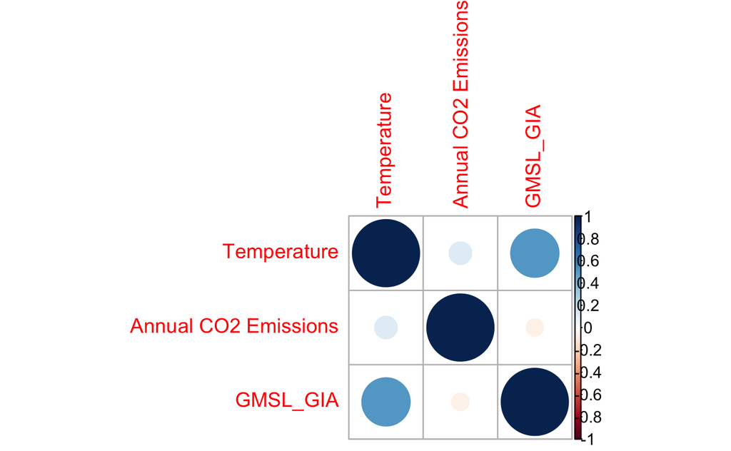

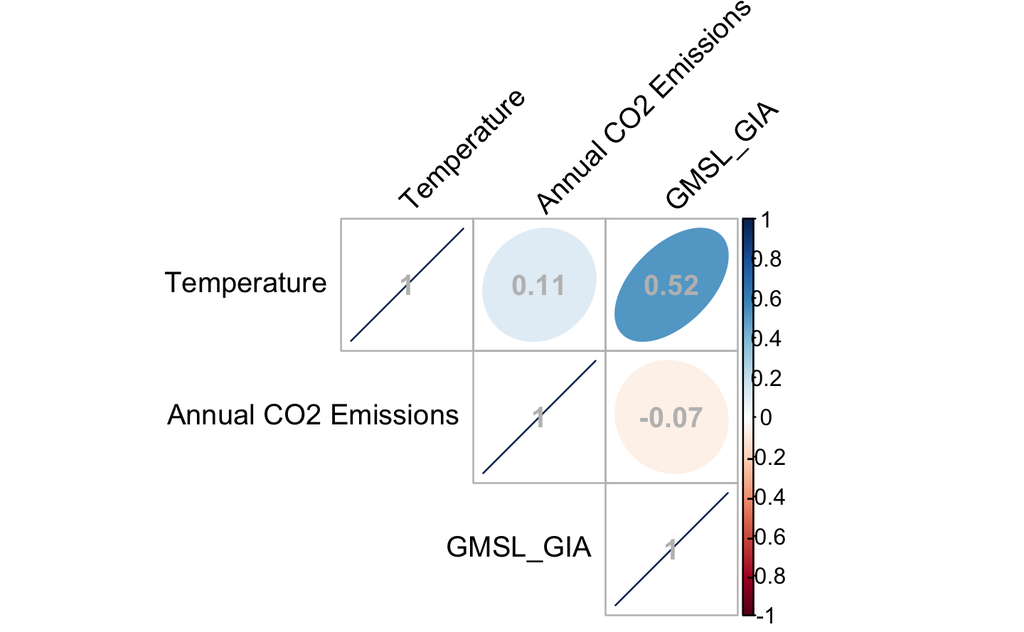

```r
subset_data <- data_RQ3[, c("Temperature", "Annual CO2 Emissions", "GMSL_GIA")]
correlation_matrix <- cor(subset_data, use = "complete.obs")
corrplot(correlation_matrix, method = "circle")

# Customized corrplot for the subset
corrplot(
  correlation_matrix,
  method = "ellipse",
  type = "upper",
  tl.col = "black",
  tl.srt = 45,
  addCoef.col = "gray"
)
```

```r
# We create a new variable 'SharkAttacksCount' representing the frequency of shark attacks per year
count_shark_attacks <- data_RQ3 %>%
  group_by(Year, ISO_Code) %>%
  summarize(SharkAttacksCount = n())


# Then, we merge the aggregated shark attacks data back to your original dataset (merged_data3) based on the 'year' and 'ISO_Code' variables. We do this, so as to be able to run a the regression
data_RQ3 <- merge(data_RQ3, count_shark_attacks, by = c("Year", "ISO_Code"), all.x = TRUE)

# FIRST MODEL
filtered_data <- data_RQ3 %>%
  filter(ISO_Code %in% c("USA", "ZAF", "AUS"))

model <- lm(SharkAttacksCount ~ Temperature + GMSL_GIA + `Annual CO2 Emissions`, data = filtered_data)
```

**Regression for shark attacks against climate change factors**

|  | *Dependent variable:* |
| --- | --- |
|  | SharkAttacksCount |
| Temperature | 4.34000*** |
|  | (0.55100) |
| GMSL_GIA | 0.28600*** |
|  | (0.01130) |
| `Annual CO2 Emissions` | 0.00000*** |
|  | (0.00000) |
| Constant | 8.00000*** |
|  | (0.56200) |
| Observations | 1,717 |
| R<sup>2</sup> | 0.79200 |
| Adjusted R<sup>2</sup> | 0.79100 |
| Residual Std. Error | 8.83000 (df = 1713) |
| F Statistic | 2,171.00000*** (df = 3; 1713) |
| *Note:* | p<0.1; p<0.05; p<0.01 |

The results of our regression are really interesting to analyse! The statistical significance of the coefficients related to temperature change, sea level change, and CO2 emissions indicates their important contribution to our predictive model. The complex interaction between environmental dynamics and shark activity is highlighted by the positive correlation found between the annual frequency of shark attacks and these three climate change parameters.

The constant term denotes the baseline frequency of shark attacks when all environmental factors are held constant, and it is equal to **8.00035**. This means that, when we hold all the parameters to 0 (more precisely, if there is no detection of climate change), we would still have a positive amount of shark attacks.The interpretation is fairly clear, indicating that shark attacks are obviously not caused by climate change per se.

Our second finding is that the temperature change beta coefficient is 4.34176, and the significance level is indicated by three asterisks (***). This highlights a strong and favorable correlation between temperature changes and the number of shark attacks. Similarly, the sea level change beta coefficient, which is marked with three asterisks and registers at 0.28554, indicates a significant positive correlation between rising sea levels and an increase in shark attacks. Finally, the beta coefficient for CO2 emissions is very close to zero, still remaining positive. This notifies us that an increase of CO2 emissions leads to a very small increase of shark attacks.

Finally, we also notice that $R^2$ is equal to 0,7917, meaning that, in this context, our variables explain 79,17% of the variation of our variables of interest.